# Complemento Laboratorio Nº5

Análisis de Datos

Profesores: Ramón H. Cornejo-Muñoz y Felipe Rojas Profesor Ayudante de Laboratorio: Mauricio Vargas Ayudantes: Franco Mansilla y Mauricio Díaz Universidad Nacional Andrés Bello

## Ejercicio

A partir del modelo con mejor ajuste del [Laboratorio Nº5](http://pachamaltese.github.io/analisis-de-datos-unab/laboratorio5/desarrollo-laboratorio5.html) anterior obtenga:

- Predicción del output
- Productividad marginal
- Razón técnica de sustitución
- Elasticidad producto-factor
- Elasticidad de escala
- Razón técnica relativa de sustitución
- Tamaño óptimo de planta

## Algunas definiciones

Productividad marginal $MP_{i} = \frac{\partial y}{\partial x_i}$

Elasticidad producto-factor $\epsilon_i = \frac{\partial \ln (y)}{\partial \ln(x_i)} = \beta_i + \sum_{j=1}^n \beta_{ij} \ln(x_j)$

Elasticidad de escala $\mathcal{E} = \sum_{i=1}^n \epsilon_i$

Tener en cuenta que $\frac{\partial \ln(y)}{\partial \ln(x_i)} = \frac{\Delta y}{y} \frac{x_i}{\Delta x_i} \: \Longrightarrow \: MP_i = \frac{\partial y}{\partial x_i} = \frac{y}{x_i} \frac{\partial \ln(y)}{\partial \ln(x_i)} = \frac{y}{x_i}\epsilon_i$

Lo más eficiente es proceder en el siguiente orden:

- Elasticidad producto-factor
- Elasticidad de escala
- Tamaño óptimo de planta
- Productividad marginal
- Razón técnica de sustitución
- Razón técnica relativa de sustitución

## Función con mejor ajuste

A partir de los test realizados en el laboratorio la función que mejor representa el proceso de producción es: $\ln y = \beta_0 + \sum_i \beta_i \ln x_i + \frac{1}{2} \sum_i \sum_j \beta_{ij} \ln x_i \ln x_j$

## Estimación de parámetros

```r
library("miscTools")
library("lmtest")
data("appleProdFr86", package = "micEcon")
data <- appleProdFr86
rm(appleProdFr86)

data$qCap <- data$vCap/data$pCap
data$qLab <- data$vLab/data$pLab
data$qMat <- data$vMat/data$pMat
```

```r
prodTL <- lm(log(qOut) ~ log(qCap) + log(qLab) + log(qMat) + I(0.5*log(qCap)^2)
             + I(0.5*log(qLab)^2) + I(0.5*log(qMat)^2) + I(log(qCap)*log(qLab))
             + I(log(qCap)*log(qMat)) + I(log(qLab)*log(qMat)), data = data)
```

## Predicción del output

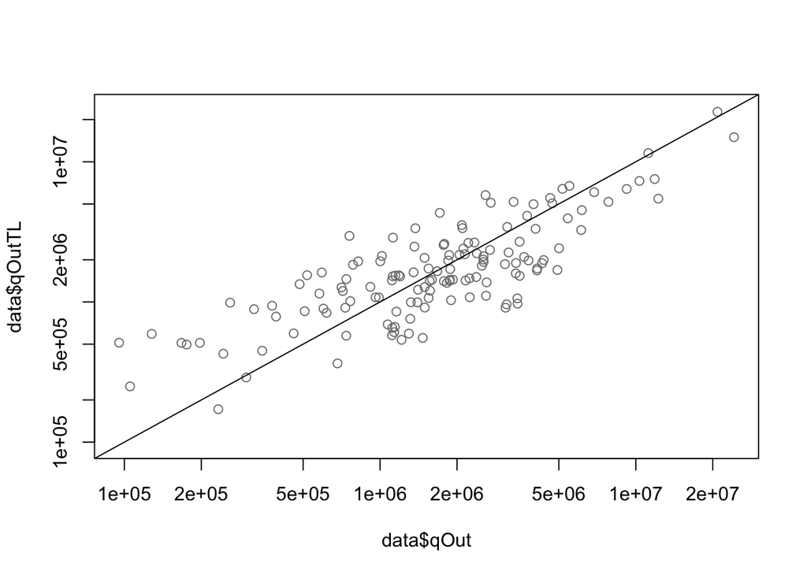

```r
data$qOutTL <- exp(fitted(prodTL))
compPlot(data$qOut, data$qOutTL, log = "xy", col="gray50")
```

## Elasticidad producto-factor

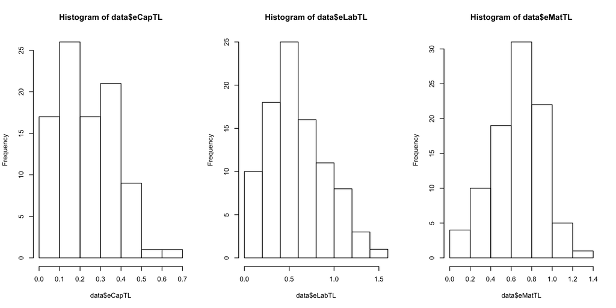

```r
b1 <- coef(prodTL)["log(qCap)"]
b2 <- coef(prodTL)["log(qLab)"]
b3 <- coef(prodTL)["log(qMat)"]
b11 <- coef(prodTL)["I(0.5 * log(qCap)^2)"]
b22 <- coef(prodTL)["I(0.5 * log(qLab)^2)"]
b33 <- coef(prodTL)["I(0.5 * log(qMat)^2)"]
b12 <- b21 <- coef(prodTL)["I(log(qCap) * log(qLab))"]
b13 <- b31 <- coef(prodTL)["I(log(qCap) * log(qMat))"]
b23 <- b32 <- coef(prodTL)["I(log(qLab) * log(qMat))"]

data$eCapTL <- with(data, b1 + b11*log(qCap) + b12*log(qLab) + b13*log(qMat))
data$eLabTL <- with(data, b2 + b21*log(qCap) + b22*log(qLab) + b23*log(qMat))
data$eMatTL <- with(data, b3 + b31*log(qCap) + b32*log(qLab) + b33*log(qMat))
data <- data[data$eCapTL >= 0 & data$eLabTL >= 0 & data$eMatTL >= 0,]
par(mfrow=c(1,3)); hist(data$eCapTL); hist(data$eLabTL); hist(data$eMatTL)
```

## Elasticidad de escala

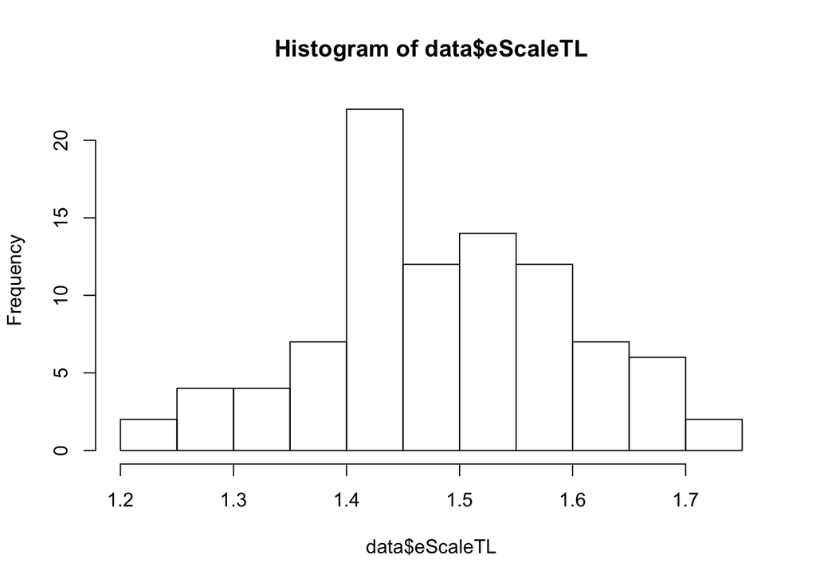

```r
data$eScaleTL <- data$eCapTL + data$eLabTL + data$eMatTL
hist(data$eScaleTL)
```

## Tamaño óptimo de planta (en base a elasticidad de escala)

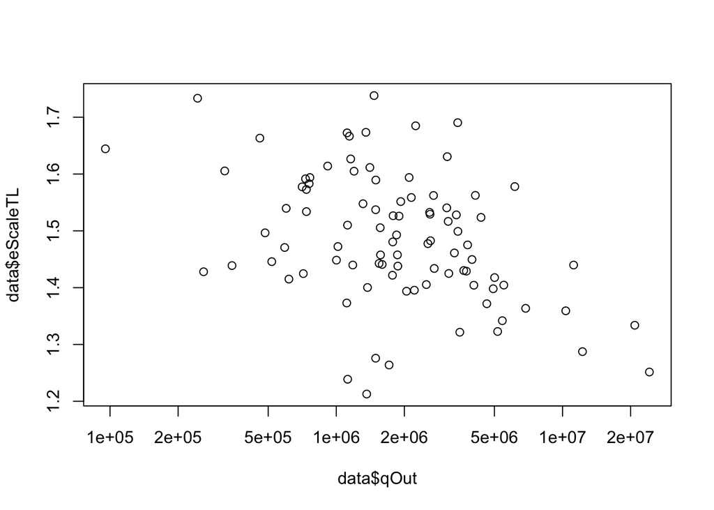

```r
plot(data$qOut, data$eScaleTL, log = "x")
```

## Productividad marginal

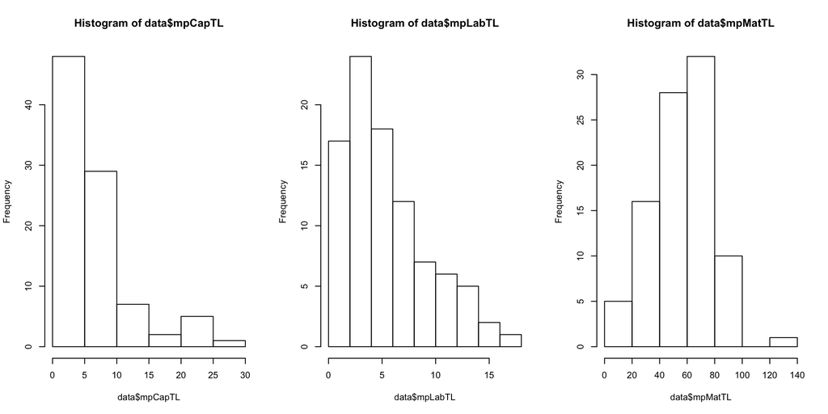

```r
data$mpCapTL <- with(data, eCapTL * qOutTL / qCap)
data$mpLabTL <- with(data, eLabTL * qOutTL / qLab)
data$mpMatTL <- with(data, eMatTL * qOutTL / qMat)
par(mfrow=c(1,3)); hist(data$mpCapTL); hist(data$mpLabTL); hist(data$mpMatTL)
```

Que la productividad marginal sea negativa es un indicio de mala especificación del modelo. Se verán los detalles sobre esto en los laboratorios siguientes.

## Razón técnica de sustitución

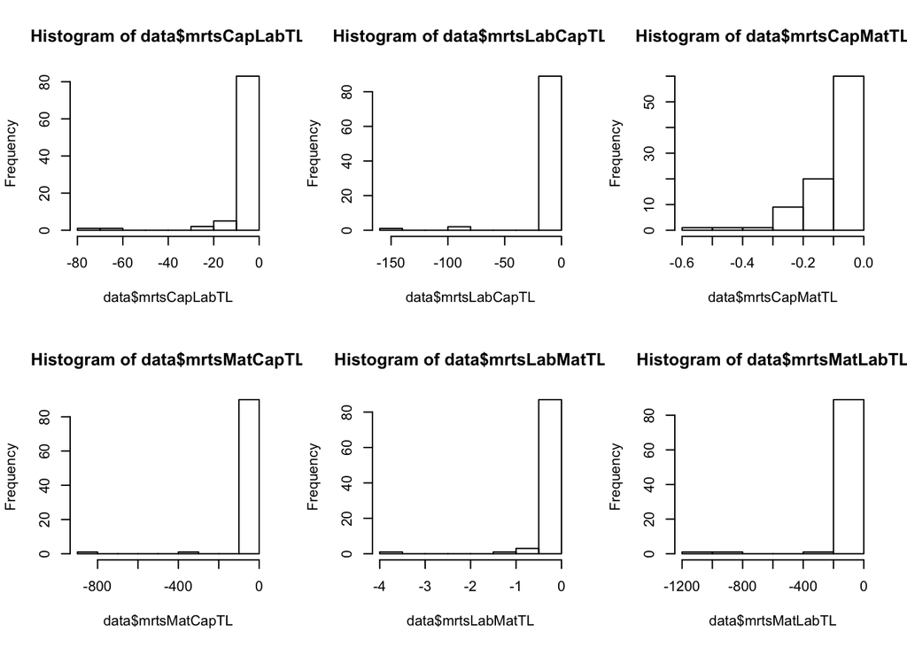

```r
data$mrtsCapLabTL <- with(data, - mpCapTL / mpLabTL)
data$mrtsLabCapTL <- with(data, - mpLabTL / mpCapTL)
data$mrtsCapMatTL <- with(data, - mpCapTL / mpMatTL)
data$mrtsMatCapTL <- with(data, - mpMatTL / mpCapTL)
data$mrtsLabMatTL <- with(data, - mpLabTL / mpMatTL)
data$mrtsMatLabTL <- with(data, - mpMatTL / mpLabTL)

par(mfrow=c(2,3)); hist(data$mrtsCapLabTL); hist(data$mrtsLabCapTL); hist(data$mrtsCapMatTL);
hist(data$mrtsMatCapTL); hist(data$mrtsLabMatTL); hist(data$mrtsMatLabTL)
```

## Razón técnica relativa de sustitución

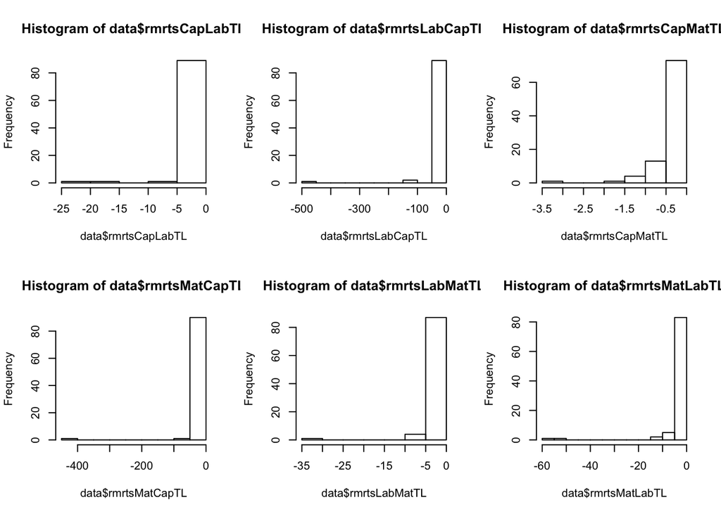

```r
data$rmrtsCapLabTL <- with(data, - eCapTL / eLabTL)
data$rmrtsLabCapTL <- with(data, - eLabTL / eCapTL)
data$rmrtsCapMatTL <- with(data, - eCapTL / eMatTL)
data$rmrtsMatCapTL <- with(data, - eMatTL / eCapTL)
data$rmrtsLabMatTL <- with(data, - eLabTL / eMatTL)
data$rmrtsMatLabTL <- with(data, - eMatTL / eLabTL)

par(mfrow=c(2,3)); hist(data$rmrtsCapLabTL); hist(data$rmrtsLabCapTL); hist(data$rmrtsCapMatTL);
hist(data$rmrtsMatCapTL); hist(data$rmrtsLabMatTL); hist(data$rmrtsMatLabTL)
```